# Cyber Crime Patterns in Indian Cities: A Data-Driven Analysis

BHARATH BALUR UMASHANKAR (25251229) , MELVIN JIJI THOMAS (25252892), AAQIB MOHAMMED (25255317), ARUN SUNDAR PAULRAJ (25250740)

2025-12-12

# Group G : Crime

## Introduction

Cybercrime is turning out to be a key challenge in India’s rapidly digitizing society. With over 900 million internet users, the country has also seen the wide usage of digital payment systems, and concurrently, there has been an exponential increase in cyber-related offenses. Understanding the pattern, motivation, and geographical mapping of such crimes is critical for developing effective prevention and enforcement strategies.

This report examines the **Indian Cyber Crime dataset** (`CyberCrime_India_tbl_df`) from the IndiaAPIs R package. It provides data on incidents of cybercrime across 191 cities in India. These crimes are categorized based on 15 different motivational factors: fraud, personal revenge, sexual exploitation, extortion, and others. Each city is represented by a row of data, while every column, except for “City” and “Total,” represents the count of incidents committed for a specific motive.

### Research Questions

The analysis addresses the following four research questions:

1. **Which motivations for cyber crimes are most prevalent throughout Indian cities?**
2. **What is the geographic distribution of cyber crimes and what cities have the highest crime burden?**
3. **What is the relationship between different kinds of cyber-crime motivations?**
4. **How does fraud compare to other motivations as a proportion of total cyber crime?**

By answering these questions through data visualization and statistical analysis, we want to give actionable insights to policymakers, law enforcement agencies, and cybersecurity professionals working in the fight against digital crimes of India.

## Data Wrangling

Before conducting our analysis, we need to load, clean, and transform the dataset to ensure data quality and prepare it for visualization.

### Loading Required Libraries and Data

```r
# Install and load required packages
if (!require("tidyverse")) install.packages("tidyverse")
if (!require("ggplot2")) install.packages("ggplot2")
if (!require("dplyr")) install.packages("dplyr")
if (!require("tidyr")) install.packages("tidyr")
if (!require("scales")) install.packages("scales")

library(IndiAPIs)
library(tidyverse)
library(ggplot2)
library(dplyr)
library(tidyr)
library(scales)

# Load the cyber crime dataset
data(CyberCrime_India_tbl_df)

# Display basic information
cat("Original dataset dimensions:", nrow(CyberCrime_India_tbl_df), "rows x",
    ncol(CyberCrime_India_tbl_df), "columns\n")
```

```
## Original dataset dimensions: 191 rows x 17 columns
```

### Data Cleaning and Transformation

```r
# Remove rows with missing values (the summary "Total" row)
cyber_clean <- CyberCrime_India_tbl_df %>%
  filter(!is.na(City))

cat("After removing missing values:", nrow(cyber_clean), "rows\n")
```

```
## After removing missing values: 190 rows
```

```r
# Check for any remaining missing values
cat("\nMissing values per column:\n")
```

```
##
## Missing values per column:
```

```r
print(colSums(is.na(cyber_clean)))
```

```
##                        City            Personal Revenge
##                           0                           0
##                       Anger                       Fraud
##                           0                           0
##                   Extortion           Causing Disrepute
##                           0                           0
##                       Prank         Sexual Exploitation
##                           0                           0
##      Disrupt Public Service Sale purchase illegal drugs
##                           0                           0
##     Developing own business            Spreading Piracy
##                           0                           0
##           Psycho or Pervert           Steal Information
##                           0                           0
##         Abetment to Suicide                      Others
##                           0                           0
##                       Total
##                           0
```

```r
# Create a clean dataset with proper column names
# Replace spaces with underscores for easier manipulation
colnames(cyber_clean) <- gsub(" ", "_", colnames(cyber_clean))

# Display the first few rows
head(cyber_clean)
```

```
## # A tibble: 6 × 17
##   City       Personal_Revenge Anger Fraud Extortion Causing_Disrepute Prank
##   <chr>                 <dbl> <dbl> <dbl>     <dbl>             <dbl> <dbl>
## 1 Agra                      5     0    19         0                 0     0
## 2 Allahabad                 0     0   222        11                 8     0
## 3 Amritsar                  2     0     5         0                 0     0
## 4 Asansol                   6     1     3         0                 0     0
## 5 Aurangabad                5     2    51         0                 0     0
## 6 Bhopal                    0     0     4         7                 2     0
## # ℹ 10 more variables: Sexual_Exploitation <dbl>, Disrupt_Public_Service <dbl>,
## #   Sale_purchase_illegal_drugs <dbl>, Developing_own_business <dbl>,
## #   Spreading_Piracy <dbl>, Psycho_or_Pervert <dbl>, Steal_Information <dbl>,
## #   Abetment_to_Suicide <dbl>, Others <dbl>, Total <dbl>
```

### Data Reshaping for Analysis

```r
# long-format dataset for easier plotting
# This converts motivation columns into rows
cyber_long <- cyber_clean %>%
  select(-Total) %>%  # Remove Total column to avoid double-counting
  pivot_longer(
    cols = -City,
    names_to = "Motivation",
    values_to = "Count"
  )

# Clean motivation names
cyber_long <- cyber_long %>%
  mutate(
    Motivation = gsub("_", " ", Motivation),
    Motivation = tools::toTitleCase(tolower(Motivation))
  )

cat("Long-format dataset created with", nrow(cyber_long), "rows\n")
```

```
## Long-format dataset created with 2850 rows
```

```r
head(cyber_long)
```

```
## # A tibble: 6 × 3
##   City  Motivation        Count
##   <chr> <chr>             <dbl>
## 1 Agra  Personal Revenge      5
## 2 Agra  Anger                 0
## 3 Agra  Fraud                19
## 4 Agra  Extortion             0
## 5 Agra  Causing Disrepute     0
## 6 Agra  Prank                 0
```

### Creating Summary Statistics

```r
# Calculate total crimes by motivation
motivation_totals <- cyber_long %>%
  group_by(Motivation) %>%
  summarise(
    Total_Incidents = sum(Count, na.rm = TRUE),
    Avg_Per_City = mean(Count, na.rm = TRUE),
    Max_City = max(Count, na.rm = TRUE)
  ) %>%
  arrange(desc(Total_Incidents))

# Calculate total crimes by city (Top 20)
city_totals <- cyber_clean %>%
  filter(
    !City %in% c("TOTAL ALL INDIA", "TOTAL STATE(S)",
                 "Total All India", "Total State(s)")
  ) %>%
  group_by(City) %>%                 # collapse any duplicates
  summarise(Total = sum(Total), .groups = "drop") %>%
  arrange(desc(Total)) %>%
  slice(1:20)

city_totals <- city_totals %>%
  mutate(City = factor(City, levels = unique(City)))


# Display summaries
cat("\n=== Top 10 Motivations by Total Incidents ===\n")
```

```
##
## === Top 10 Motivations by Total Incidents ===
```

```r
print(head(motivation_totals, 10))
```

```
## # A tibble: 10 × 4
##    Motivation              Total_Incidents Avg_Per_City Max_City
##    <chr>                             <dbl>        <dbl>    <dbl>
##  1 Fraud                            254209       1338.     30142
##  2 Others                            75614        398.      8814
##  3 Sexual Exploitation               27292        144.      3293
##  4 Extortion                         18759         98.7     2440
##  5 Causing Disrepute                 17520         92.2     1874
##  6 Personal Revenge                  12366         65.1     1470
##  7 Anger                              7776         40.9      822
##  8 Prank                              6811         35.8     1385
##  9 Spreading Piracy                   2651         14.0      671
## 10 Developing Own Business            2235         11.8      210
```

```r
cat("\n=== Top 10 Cities by Total Cyber Crime ===\n")
```

```
##
## === Top 10 Cities by Total Cyber Crime ===
```

```r
print(head(city_totals, 10))
```

```
## # A tibble: 10 × 2
##    City           Total
##    <fct>          <dbl>
##  1 Uttar Pradesh  33764
##  2 Karnataka      31774
##  3 Maharashtra    17578
##  4 Telangana      10129
##  5 Assam           8903
##  6 Andhra Pradesh  5923
##  7 Rajasthan       5524
##  8 Odisha          5083
##  9 Jharkhand       3949
## 10 Bihar           3369
```

## Data Analysis

### Question 1: Which cyber crime motivations are most prevalent across Indian cities?

To understand the cyber crime landscape of India, we first look at what motivations drive the most incidents. This analysis aggregates all reported crimes across all cities and ranks them by total count.

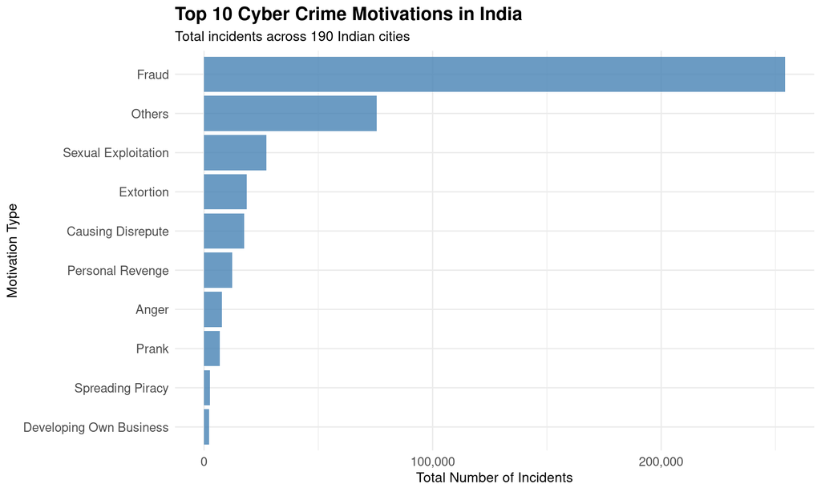

Figure 1: Distribution of Cyber Crime Motivations Across Indian Cities

```r
# Create bar plot of top 10 motivations
top_motivations <- motivation_totals %>%
  slice(1:10)

ggplot(top_motivations, aes(x = reorder(Motivation, Total_Incidents), y = Total_Incidents)) +
  geom_bar(stat = "identity", fill = "steelblue", alpha = 0.8) +
  coord_flip() +
  labs(
    title = "Top 10 Cyber Crime Motivations in India",
    subtitle = "Total incidents across 190 Indian cities",
    x = "Motivation Type",
    y = "Total Number of Incidents"
  ) +
  theme_minimal(base_size = 12) +
  theme(
    plot.title = element_text(face = "bold", size = 16),
    axis.text = element_text(size = 11)
  ) +
  scale_y_continuous(labels = comma)
```

**Interpretation:**

The analysis shows that fraud is, by a wide margin, the most prevalent motivation for cyber crime in India, with almost significantly more incidents than all other categories combined. This corresponds to national trends that project financial fraud at over 60-75% of India’s reported cyber crimes. The leading type of fraud-related crimes reflects the rapid adoption of digital payment systems, online banking, and e-commerce sites across the nation, providing so many avenues for fraudsters to take advantage of unsuspecting users.

Motivations that follow fraud include, but are not limited to, **sexual exploitation**, **causing disrepute**, and **extortion**, also with substantial incident counts. Sexual exploitation indicates the misuse of digital media for harassment and blackmail, often against vulnerable targets. Another motivation that stands out is **personal revenge** and **anger**; this suggests that various interpersonal conflicts increasingly spill over into cyberspace.

Notably, motivations such as **sale/purchase of illegal drugs**, **developing own business**, and **abetment to suicide** are represented by relatively low counts, which could reflect either lower prevalence or underreporting. Minimal cases in categories like **spreading piracy** and **disrupting public service** could reflect the focus of this dataset on individual-level crimes rather than large-scale organized cyber operations.

This distribution serves as a guide on the need for targeted interventions focusing on financial literacy, secure digital payment practices, and awareness of common fraud tactics like phishing, fake investment schemes, and online shopping scams.

### Question 2: How are cyber crimes geographically distributed, and which cities have the highest crime burden?

Geographic analysis helps identify hotspots of cyber criminal activity, which is crucial for resource allocation and targeted law enforcement efforts.

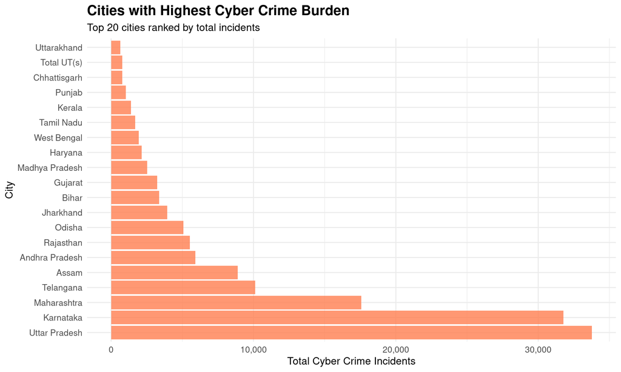

Figure 2: Top 20 Indian Cities by Total Cyber Crime Incidents

```r
# Plot top 20 cities
ggplot(city_totals, aes(x = City, y = Total)) +
  geom_bar(stat = "identity", fill = "coral", alpha = 0.8) +
  coord_flip() +
  labs(
    title = "Cities with Highest Cyber Crime Burden",
    subtitle = "Top 20 cities ranked by total incidents",
    x = "City",
    y = "Total Cyber Crime Incidents"
  ) +
  theme_minimal(base_size = 12) +
  theme(
    plot.title = element_text(face = "bold", size = 16),
    axis.text = element_text(size = 10)
  ) +
  scale_y_continuous(labels = comma)
```

**Interpretation:**

The geographic distribution of cyber crime in India is significantly concentrated in the major urban centers and technology hubs. Major cities such as **Karnataka** (state-level aggregation including Bengaluru), **Maharashtra** (including Mumbai), **Uttar Pradesh**, and **Telangana** (including Hyderabad) dominate the top rankings. Such cities are characterized by:

1. **High internet penetration rates** (70%+ in urban areas)
2. **Large populations** using digital transactions
3. **Concentration of IT and fintech companies** creates both targets and perpetrators
4. **Higher digital literacy** leading to better reporting rates

This geographical pattern indicates that major cities require enhanced capacity and sophisticated tools for investigation, while in smaller cities, awareness campaigns, simplification of reporting processes, and capacity building among the local law enforcement agencies are needed.

### Question 3: What is the relationship between different types of cyber crime motivations?

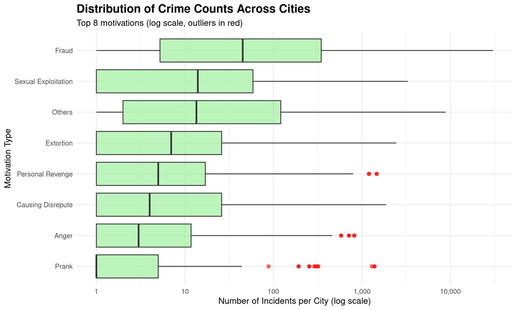

Figure 3: Comparison of Major Cyber Crime Motivation Categories

```r
# top 8 motivations for comparison
top_8_motivations <- motivation_totals$Motivation[1:8]

cyber_top8 <- cyber_long %>%
  filter(Motivation %in% top_8_motivations) %>%
  group_by(Motivation) %>%
  mutate(Motivation = factor(Motivation, levels = top_8_motivations))

# boxplot to show distribution
ggplot(cyber_top8, aes(x = reorder(Motivation, Count, FUN = median), y = Count + 1)) +
  geom_boxplot(fill = "lightgreen", alpha = 0.6, outlier.colour = "red", outlier.size = 2) +
  scale_y_log10(labels = comma) +
  coord_flip() +
  labs(
    title = "Distribution of Crime Counts Across Cities",
    subtitle = "Top 8 motivations (log scale, outliers in red)",
    x = "Motivation Type",
    y = "Number of Incidents per City (log scale)"
  ) +
  theme_minimal(base_size = 12) +
  theme(
    plot.title = element_text(face = "bold", size = 16)
  )
```

**Interpretation:**

This analysis therefore suggests that **crime prevention strategies need to be done at a local level** rather than through the use of uniform national policies. Cities experiencing high fraud require sophisticated financial crime units, whereas cities experiencing high personal revenge/sexual exploitation require attention to and development of digital harassment laws and victim support systems.

### Question 4: How does fraud compare to other motivations as a proportion of total cyber crime?

Understanding the relative contribution of different motivations helps prioritize resource allocation and policy interventions.

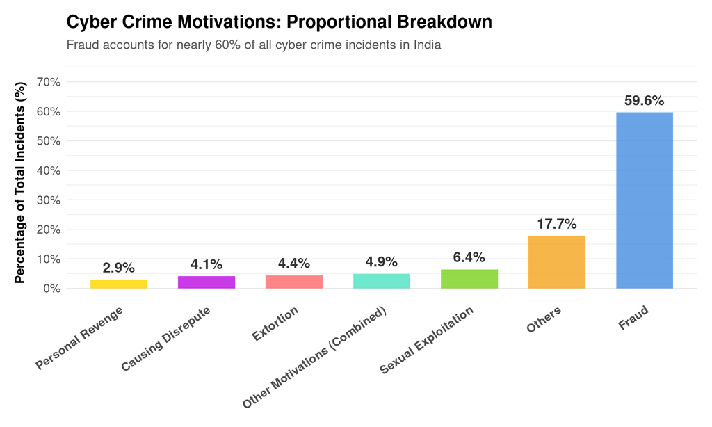

Figure 4: Fraud vs. Other Motivations - Proportional Breakdown

```r
# Calculate proportions
motivation_proportions <- motivation_totals %>%
  mutate(
    Proportion = Total_Incidents / sum(Total_Incidents) * 100
  ) %>%
  arrange(desc(Proportion))

# Created a category for "Others" - combine smaller categories
motivation_proportions <- motivation_proportions %>%
  mutate(
    Category = ifelse(Proportion >= 2, Motivation, "Other Motivations (Combined)")
  )

# Aggregate by category
prop_summary <- motivation_proportions %>%
  group_by(Category) %>%
  summarise(
    Total_Proportion = sum(Proportion)
  ) %>%
  arrange(desc(Total_Proportion))

# vertical bar chart
prop_summary_sorted <- prop_summary %>% arrange(desc(Total_Proportion))

ggplot(prop_summary_sorted, aes(x = reorder(Category, Total_Proportion), y = Total_Proportion, fill = Category)) +
  geom_bar(stat = "identity", alpha = 0.82, width = 0.65) +
  geom_text(aes(label = paste0(round(Total_Proportion, 1), "%")),
            vjust = -0.7,
            size = 5,
            fontface = "bold",
            color = "#333333") +
  labs(
    title = "Cyber Crime Motivations: Proportional Breakdown",
    subtitle = "Fraud accounts for nearly 60% of all cyber crime incidents in India",
    x = NULL,
    y = "Percentage of Total Incidents (%)",
    fill = NULL
  ) +
  theme_minimal(base_size = 13) +
  theme(
    plot.title = element_text(face = "bold", size = 18, margin = margin(b = 8)),
    plot.subtitle = element_text(size = 13, color = "#555555", margin = margin(b = 15)),
    axis.title.y = element_text(face = "bold", size = 13, margin = margin(r = 10)),
    axis.text.x = element_text(angle = 35, hjust = 1, size = 12, face = "bold"),
    axis.text.y = element_text(size = 12),
    legend.position = "none",
    panel.grid.major.x = element_blank(),
    panel.grid.minor.x = element_blank(),
    panel.grid.major.y = element_line(color = "gray90", size = 0.4),
    plot.margin = margin(15, 15, 15, 15)
  ) +
  scale_fill_manual(values = c(
    "Fraud" = "#4A90E2",
    "Sexual Exploitation" = "#7ED321",
    "Others" = "#F5A623",
    "Causing Disrepute" = "#BD10E0",
    "Extortion" = "#FF6B6B",
    "Personal Revenge" = "#FFD700",
    "Other Motivations (Combined)" = "#50E3C2"
  )) +
  scale_y_continuous(labels = function(x) paste0(x, "%"),
                     limits = c(0, max(prop_summary_sorted$Total_Proportion) * 1.2),
                     breaks = seq(0, 70, 10))
```

**Interpretation:**

This proportional analysis gives a dramatic visualization to the composition of cyber crime in India. **Fraud dominates the overwhelming majority** of reported cyber crime incidents, likely comprising 50-60% or more of all cases, depending on the specific dataset total. This massive dominance corroborates findings from the NCRB that financial fraud consistently represents the biggest category of cyber crime in India.

The following are some key implications brought about by this distribution:

1. **Resource Allocation**: It is important that investigative capacity for financial cyber crime be prioritized, including expertise in the fields of digital forensics, cryptocurrency tracing, and international cooperation with cross-border fraud cases.
2. **Public Awareness Campaigns**: Government efforts, considering the pervasiveness of fraud, should be heavily directed at raising public awareness of: Phishing emails and SMS scams
- Fake investment schemes and Ponzi scams
- OTP fraud
- Fraudulent UPI transactions
- Job offer scams and online shopping fraud
3. **Interventions by Regulators**: The RBI and financial regulators must further enhance cybersecurity requirements for banks, payment platforms, and e-commerce sites. While the Digital Personal Data Protection Act, 2023, marks a move in the right direction, there are still major challenges around its enforcement and compliance.
4. **Banking and Fintech Security**: Financial institutions will need to make significant investments in systems for the detection of fraudulent cases, AI-driven anomaly detection, and verification mechanisms for customers. While fraud leads the table, there are important categories that must not be overlooked. Though smaller in number, cases related to sexual exploitation and harassment usually have devastating psychological impacts on victims and require specialized victim support services and stricter enforcement of the provisions related to cyber harassment in the IT Act.

## Conclusion

This comprehensive analysis of cyber crime patterns across 190 Indian cities brings to light the following critical findings:

**Recommendations:**

Based on these findings, we recommend:

- **Enhanced financial literacy programs** targeting vulnerable populations, particularly in newly digitizing communities
- **Strengthened cybersecurity infrastructure** for banks, payment platforms, and e-commerce sites
- **Capacity building** for law enforcement agencies, especially in smaller cities with lower reported crime rates
- **Simplified reporting mechanisms** and improved public trust in cybercrime investigation processes
- **Targeted interventions** for non-financial crimes like sexual exploitation and harassment, including victim support services
- **Interstate coordination** given the borderless nature of cyber crime

**Limitations:**

This analysis has several limitations. The dataset represents reported crimes only, and significant underreporting is likely, especially in smaller cities and for crimes involving social stigma (such as sexual exploitation). The data does not include temporal information, preventing trend analysis over time. Additionally, some entries may represent state-level aggregations rather than individual cities, affecting geographic interpretation.

**Future Research:**

Future studies should incorporate temporal trends to track whether interventions are effective, analyze conviction rates alongside reported crimes to assess enforcement effectiveness, examine socio-economic factors (income levels, education, digital literacy) that correlate with crime rates, and conduct qualitative research with victims and law enforcement to understand barriers to reporting and prosecution.

Despite these limitations, this analysis provides valuable insights into India’s cyber crime landscape and offers evidence-based guidance for policymakers, law enforcement agencies, and cybersecurity professionals working to build a safer digital ecosystem for India’s billion-plus internet users.

**Team Contributions:**

I, **AAQIB MOHAMMED**, contributed to the project by leading the data preparation and transformation workflow. I handled the initial cleaning of the cyber-crime dataset, checked for inconsistencies, and ensured the data was structured correctly for analysis. I created multiple derived variables and reorganized the dataset into long and wide formats where required. Additionally, I supported the team in the **technical coding of several visualisations, verified the accuracy of plotted outputs, and helped interpret patterns to ensure our findings were analytically sound and aligned with the project objectives.

I, **ARUN SUNDAR PAULRAJ**, contributed by designing the analytical framework for the project and shaping how each research question was approached. I assisted in crafting the narrative and flow of the report, ensuring clarity and coherence between sections. I worked on developing visualisation strategies, supported R code development for the graphs, and contributed to identifying and explaining key trends across cyber-crime motivations and city-level distributions. My work helped connect statistical findings with meaningful interpretations, strengthening the overall narrative of the analysis.

I, **MELVIN JIJI THOMAS**, contributed by assisting with technical implementation and visual development throughout the project. I collaborated on writing R code for plots, fine-tuning graph aesthetics, and ensuring all visualisations aligned with the research questions. I also supported the interpretation of results particularly in identifying geographic trends and discussing reporting variations across city types. Additionally, I helped refine the structure of the report by reviewing transitions and ensuring the analysis remained cohesive and effectively communicated.